# DATA ANALYTICS PROJECT ON HR DATA-SET OF IBM COMPANY(USA)

# IMPORTING LIBRARIES

```python
import pandas as pd
import numpy as np
import matplotlib.pyplot as plt
import seaborn as sns
import warnings
warnings.filterwarnings("ignore")
```

# Importing Dataset

```python
df = pd.read_csv("D:\Project - Kag\HR Employee Attrition\HR-Employee-Attrition.csv")
```

```python
df.head()
```

|  | Age | Attrition | BusinessTravel | DailyRate | Department | DistanceFromHome | Education | EducationField | EmployeeCount | EmployeeNumber | ... | RelationshipSatisfaction | StandardHours | StockOptionLevel | TotalWorkingYears | TrainingTimesLastYear | WorkLifeBalance | YearsAtCompany | YearsInCurrentRole | YearsSinceLastPromotion | YearsWithCurrManager |
| --- | --- | --- | --- | --- | --- | --- | --- | --- | --- | --- | --- | --- | --- | --- | --- | --- | --- | --- | --- | --- | --- |
| 0 | 41 | Yes | Travel_Rarely | 1102 | Sales | 1 | 2 | Life Sciences | 1 | 1 | ... | 1 | 80 | 0 | 8 | 0 | 1 | 6 | 4 | 0 | 5 |
| 1 | 49 | No | Travel_Frequently | 279 | Research & Development | 8 | 1 | Life Sciences | 1 | 2 | ... | 4 | 80 | 1 | 10 | 3 | 3 | 10 | 7 | 1 | 7 |
| 2 | 37 | Yes | Travel_Rarely | 1373 | Research & Development | 2 | 2 | Other | 1 | 4 | ... | 2 | 80 | 0 | 7 | 3 | 3 | 0 | 0 | 0 | 0 |
| 3 | 33 | No | Travel_Frequently | 1392 | Research & Development | 3 | 4 | Life Sciences | 1 | 5 | ... | 3 | 80 | 0 | 8 | 3 | 3 | 8 | 7 | 3 | 0 |
| 4 | 27 | No | Travel_Rarely | 591 | Research & Development | 2 | 1 | Medical | 1 | 7 | ... | 4 | 80 | 1 | 6 | 3 | 3 | 2 | 2 | 2 | 2 |

5 rows × 35 columns

# INTRODUCTION OF PROJECT

TARGET COLUMN == ATTRITION

- Attrition--> Attrition is the departure of employees from the organization for any reason or in simple words we can say that employyees who left the company
- ATTRITION "YEA"--> Employee left the organization
- ATTRITION "NO"--> Employee not left the company

WHAT WE ARE GOING TO DO IN THIS

- It will uncover the factors that lead to empoloyee attrtion
- In this project we are going to analyse that how other features of dataset is effecting "attrition"

# DOMAIN ANALYSIS

1.AGE age of an employee

2.BUSINESS TRAVEL That employee is traveling or not for business purpose.

3.DEPARTMENT In which department of company employee is working

4.DISTANCE FROM HOME That how much distance is there of an employee from hisher house to office.

5.HOURLY/DAILY/MONTHLY RATING Rating given to employee on daily, hourly and monthly basis.

6.EDUCATION FIELD From which education background employee belongs to

9.JOB LEVEL Level of job (Given in 1-5 rating). higher rating == higher job level

10.PERFORMANCE RATING How employee is performing according to his job (Given in 1-5 rating)

11.MONTHLY INCOME Monthly salary of an employee in dollars

12.PERCENTAGE SALARY HIKE How much percent salary in increasing annually

# BASIC CHECKS

```python
df.info()
```

```
<class 'pandas.core.frame.DataFrame'>
RangeIndex: 1470 entries, 0 to 1469
Data columns (total 35 columns):
 #   Column                    Non-Null Count  Dtype
---  ------                    --------------  -----
 0   Age                       1470 non-null   int64
 1   Attrition                 1470 non-null   object
 2   BusinessTravel            1470 non-null   object
 3   DailyRate                 1470 non-null   int64
 4   Department                1470 non-null   object
 5   DistanceFromHome          1470 non-null   int64
 6   Education                 1470 non-null   int64
 7   EducationField            1470 non-null   object
 8   EmployeeCount             1470 non-null   int64
 9   EmployeeNumber            1470 non-null   int64
```

[output cut: 27 more lines]

- Here information tells us that there is no null values are present in data so we need not to handle null values.
- However it can be seen that there are 9 features or columns which are of "object" datatype. so we have to handle categorical columns for our model creation

```python
df.describe()
```

|  | Age | DailyRate | DistanceFromHome | Education | EmployeeCount | EmployeeNumber | EnvironmentSatisfaction | HourlyRate | JobInvolvement | JobLevel | ... | RelationshipSatisfaction | StandardHours | StockOptionLevel | TotalWorkingYears | TrainingTimesLastYear | WorkLifeBalance | YearsAtCompany | YearsInCurrentRole | YearsSinceLastPromotion | YearsWithCurrManager |
| --- | --- | --- | --- | --- | --- | --- | --- | --- | --- | --- | --- | --- | --- | --- | --- | --- | --- | --- | --- | --- | --- |
| count | 1470.000000 | 1470.000000 | 1470.000000 | 1470.000000 | 1470.0 | 1470.000000 | 1470.000000 | 1470.000000 | 1470.000000 | 1470.000000 | ... | 1470.000000 | 1470.0 | 1470.000000 | 1470.000000 | 1470.000000 | 1470.000000 | 1470.000000 | 1470.000000 | 1470.000000 | 1470.000000 |
| mean | 36.923810 | 802.485714 | 9.192517 | 2.912925 | 1.0 | 1024.865306 | 2.721769 | 65.891156 | 2.729932 | 2.063946 | ... | 2.712245 | 80.0 | 0.793878 | 11.279592 | 2.799320 | 2.761224 | 7.008163 | 4.229252 | 2.187755 | 4.123129 |
| std | 9.135373 | 403.509100 | 8.106864 | 1.024165 | 0.0 | 602.024335 | 1.093082 | 20.329428 | 0.711561 | 1.106940 | ... | 1.081209 | 0.0 | 0.852077 | 7.780782 | 1.289271 | 0.706476 | 6.126525 | 3.623137 | 3.222430 | 3.568136 |
| min | 18.000000 | 102.000000 | 1.000000 | 1.000000 | 1.0 | 1.000000 | 1.000000 | 30.000000 | 1.000000 | 1.000000 | ... | 1.000000 | 80.0 | 0.000000 | 0.000000 | 0.000000 | 1.000000 | 0.000000 | 0.000000 | 0.000000 | 0.000000 |
| 25% | 30.000000 | 465.000000 | 2.000000 | 2.000000 | 1.0 | 491.250000 | 2.000000 | 48.000000 | 2.000000 | 1.000000 | ... | 2.000000 | 80.0 | 0.000000 | 6.000000 | 2.000000 | 2.000000 | 3.000000 | 2.000000 | 0.000000 | 2.000000 |
| 50% | 36.000000 | 802.000000 | 7.000000 | 3.000000 | 1.0 | 1020.500000 | 3.000000 | 66.000000 | 3.000000 | 2.000000 | ... | 3.000000 | 80.0 | 1.000000 | 10.000000 | 3.000000 | 3.000000 | 5.000000 | 3.000000 | 1.000000 | 3.000000 |
| 75% | 43.000000 | 1157.000000 | 14.000000 | 4.000000 | 1.0 | 1555.750000 | 4.000000 | 83.750000 | 3.000000 | 3.000000 | ... | 4.000000 | 80.0 | 1.000000 | 15.000000 | 3.000000 | 3.000000 | 9.000000 | 7.000000 | 3.000000 | 7.000000 |
| max | 60.000000 | 1499.000000 | 29.000000 | 5.000000 | 1.0 | 2068.000000 | 4.000000 | 100.000000 | 4.000000 | 5.000000 | ... | 4.000000 | 80.0 | 3.000000 | 40.000000 | 6.000000 | 4.000000 | 40.000000 | 18.000000 | 15.000000 | 17.000000 |

8 rows × 26 columns

- Here two columns (Empty_count, Standard_Hours) have std==0 so, it means they have unique values it means they are not able to use in analysis

```python
df.describe(include="O")   # "O" means objective
```

|  | Attrition | BusinessTravel | Department | EducationField | Gender | JobRole | MaritalStatus | Over18 | OverTime |
| --- | --- | --- | --- | --- | --- | --- | --- | --- | --- |
| count | 1470 | 1470 | 1470 | 1470 | 1470 | 1470 | 1470 | 1470 | 1470 |
| unique | 2 | 3 | 3 | 6 | 2 | 9 | 3 | 1 | 2 |
| top | No | Travel_Rarely | Research & Development | Life Sciences | Male | Sales Executive | Married | Y | No |
| freq | 1233 | 1043 | 961 | 606 | 882 | 326 | 673 | 1470 | 1054 |

- Here in over18 columns we only have 1 unique values so it means no analysis done on it.

# EDA (Exploratory Data Analysis)

ANALYSIS ON CATEGORICAL COLUMNS With respect to Target Column (Attrition)

Target Column == Attrition

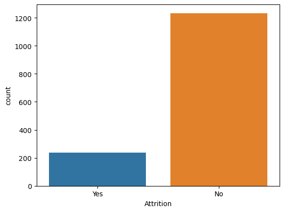

```python
sns.countplot(x=df.Attrition)
plt.show()
```

- Data of Attrition says that it has more number of "No" values and less number of "Yes"
- It can be seen that there is big difference in counts of the values so we can say that it is IMBALANCE DATA

1.IMPACT OF BUSINESS TRAVEL ON ATTRITION

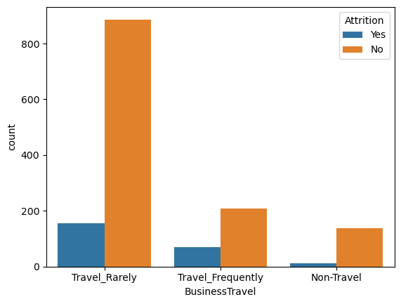

```python
sns.countplot(x=df.BusinessTravel, hue=df.Attrition)
plt.show()
```

- Graph tells us that company has more count or more no of employees who travels rarely. it means travel rate of company is less
- There are more employees which travels rarely and are not satisfied with thier job
- Non-traveller have less count as well as less attrition
2. IMPACT OF DEPARTMENT ON ATTRTTION

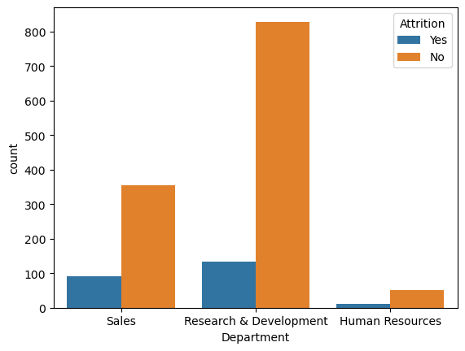

```python
sns.countplot(x=df.Department, hue=df.Attrition)
plt.show()
```

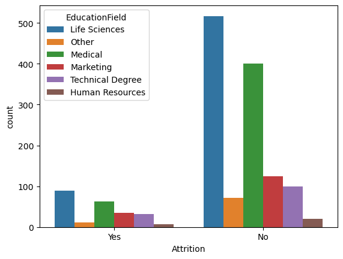

```python
sns.countplot(x=df.Attrition, hue=df.EducationField)
plt.show()
```

- First and foremost thing is that employees who are from Life Science and Medical Backgrounds are more as compared to other education fields
- Nearly 100 number of employees are there who are from Life Science education backgroudn left the company and followed by Medical educatiobn employees
- As we conclude from analysisi of Department and Attrition. here aalso HR Educational background employees have least Attrition.
4. GENDER AND ATTRTION

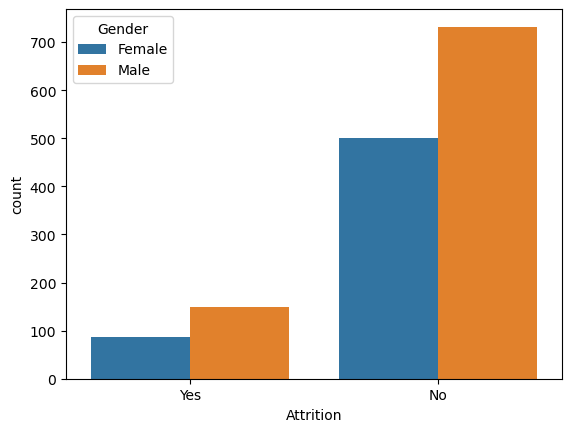

```python
sns.countplot(x=df.Attrition, hue=df.Gender)
plt.show()
```

- Male employees are more as compared to Females
- Males are more likely to quit the job rather than Females
5. OVERTIME AND ATTRITION

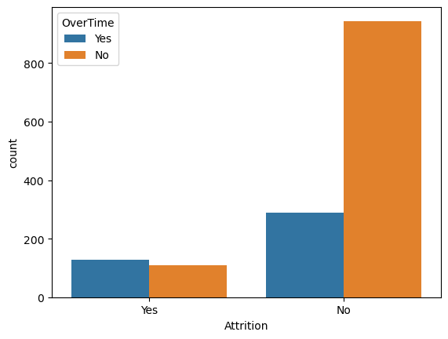

```python
sns.countplot(x=df.Attrition, hue=df.OverTime)
plt.show()
```

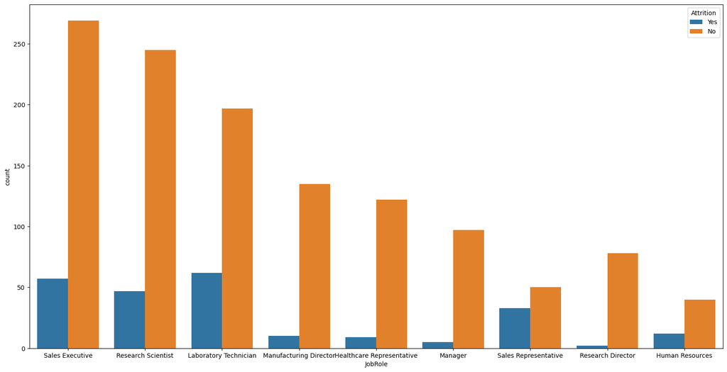

```python
plt.figure(figsize=(20,10),facecolor="white")
sns.countplot(x=df.JobRole, hue=df.Attrition)
plt.xlabel("JobRole")
plt.show()
```

- There are less no of Research Director who leaves the company
- Laibratory Technician, Sales Executive and Research Scientist are the top 3 job roles in which employees have thier Attrition Yes.
- Apart from these, it can also be seen that there are more number of employees in Sales Executive job role.